# Table of Contents

# 13. 앙상블과제

## boston데이터를 가지고 집값을 예측하는 아래 3가지의 모델을 만들고 모델을 비교하고 최적 모델의 결과를 해석하세요

### 배깅

### 랜덤포래스트

### 부스팅

```python
import pandas as pd
from sklearn.datasets import load_boston
boston= load_boston()
X = pd.DataFrame(boston.data,columns=boston.feature_names)
y = boston.target
```

```python
X
```

|  | CRIM | ZN | INDUS | CHAS | NOX | RM | AGE | DIS | RAD | TAX | PTRATIO | B | LSTAT |
| --- | --- | --- | --- | --- | --- | --- | --- | --- | --- | --- | --- | --- | --- |
| 0 | 0.00632 | 18.0 | 2.31 | 0.0 | 0.538 | 6.575 | 65.2 | 4.0900 | 1.0 | 296.0 | 15.3 | 396.90 | 4.98 |
| 1 | 0.02731 | 0.0 | 7.07 | 0.0 | 0.469 | 6.421 | 78.9 | 4.9671 | 2.0 | 242.0 | 17.8 | 396.90 | 9.14 |
| 2 | 0.02729 | 0.0 | 7.07 | 0.0 | 0.469 | 7.185 | 61.1 | 4.9671 | 2.0 | 242.0 | 17.8 | 392.83 | 4.03 |
| 3 | 0.03237 | 0.0 | 2.18 | 0.0 | 0.458 | 6.998 | 45.8 | 6.0622 | 3.0 | 222.0 | 18.7 | 394.63 | 2.94 |
| 4 | 0.06905 | 0.0 | 2.18 | 0.0 | 0.458 | 7.147 | 54.2 | 6.0622 | 3.0 | 222.0 | 18.7 | 396.90 | 5.33 |
| ... | ... | ... | ... | ... | ... | ... | ... | ... | ... | ... | ... | ... | ... |
| 501 | 0.06263 | 0.0 | 11.93 | 0.0 | 0.573 | 6.593 | 69.1 | 2.4786 | 1.0 | 273.0 | 21.0 | 391.99 | 9.67 |
| 502 | 0.04527 | 0.0 | 11.93 | 0.0 | 0.573 | 6.120 | 76.7 | 2.2875 | 1.0 | 273.0 | 21.0 | 396.90 | 9.08 |
| 503 | 0.06076 | 0.0 | 11.93 | 0.0 | 0.573 | 6.976 | 91.0 | 2.1675 | 1.0 | 273.0 | 21.0 | 396.90 | 5.64 |
| 504 | 0.10959 | 0.0 | 11.93 | 0.0 | 0.573 | 6.794 | 89.3 | 2.3889 | 1.0 | 273.0 | 21.0 | 393.45 | 6.48 |
| 505 | 0.04741 | 0.0 | 11.93 | 0.0 | 0.573 | 6.030 | 80.8 | 2.5050 | 1.0 | 273.0 | 21.0 | 396.90 | 7.88 |

506 rows × 13 columns

```python
y
```

```
array([24. , 21.6, 34.7, 33.4, 36.2, 28.7, 22.9, 27.1, 16.5, 18.9, 15. ,
       18.9, 21.7, 20.4, 18.2, 19.9, 23.1, 17.5, 20.2, 18.2, 13.6, 19.6,
       15.2, 14.5, 15.6, 13.9, 16.6, 14.8, 18.4, 21. , 12.7, 14.5, 13.2,
       13.1, 13.5, 18.9, 20. , 21. , 24.7, 30.8, 34.9, 26.6, 25.3, 24.7,
       21.2, 19.3, 20. , 16.6, 14.4, 19.4, 19.7, 20.5, 25. , 23.4, 18.9,
       35.4, 24.7, 31.6, 23.3, 19.6, 18.7, 16. , 22.2, 25. , 33. , 23.5,
       19.4, 22. , 17.4, 20.9, 24.2, 21.7, 22.8, 23.4, 24.1, 21.4, 20. ,
       20.8, 21.2, 20.3, 28. , 23.9, 24.8, 22.9, 23.9, 26.6, 22.5, 22.2,
       23.6, 28.7, 22.6, 22. , 22.9, 25. , 20.6, 28.4, 21.4, 38.7, 43.8,
       33.2, 27.5, 26.5, 18.6, 19.3, 20.1, 19.5, 19.5, 20.4, 19.8, 19.4,
       21.7, 22.8, 18.8, 18.7, 18.5, 18.3, 21.2, 19.2, 20.4, 19.3, 22. ,
       20.3, 20.5, 17.3, 18.8, 21.4, 15.7, 16.2, 18. , 14.3, 19.2, 19.6,
       23. , 18.4, 15.6, 18.1, 17.4, 17.1, 13.3, 17.8, 14. , 14.4, 13.4,
       15.6, 11.8, 13.8, 15.6, 14.6, 17.8, 15.4, 21.5, 19.6, 15.3, 19.4,
       17. , 15.6, 13.1, 41.3, 24.3, 23.3, 27. , 50. , 50. , 50. , 22.7,
       25. , 50. , 23.8, 23.8, 22.3, 17.4, 19.1, 23.1, 23.6, 22.6, 29.4,
       23.2, 24.6, 29.9, 37.2, 39.8, 36.2, 37.9, 32.5, 26.4, 29.6, 50. ,
       32. , 29.8, 34.9, 37. , 30.5, 36.4, 31.1, 29.1, 50. , 33.3, 30.3,
       34.6, 34.9, 32.9, 24.1, 42.3, 48.5, 50. , 22.6, 24.4, 22.5, 24.4,
       20. , 21.7, 19.3, 22.4, 28.1, 23.7, 25. , 23.3, 28.7, 21.5, 23. ,
       26.7, 21.7, 27.5, 30.1, 44.8, 50. , 37.6, 31.6, 46.7, 31.5, 24.3,
       31.7, 41.7, 48.3, 29. , 24. , 25.1, 31.5, 23.7, 23.3, 22. , 20.1,
       22.2, 23.7, 17.6, 18.5, 24.3, 20.5, 24.5, 26.2, 24.4, 24.8, 29.6,
       42.8, 21.9, 20.9, 44. , 50. , 36. , 30.1, 33.8, 43.1, 48.8, 31. ,
       36.5, 22.8, 30.7, 50. , 43.5, 20.7, 21.1, 25.2, 24.4, 35.2, 32.4,
       32. , 33.2, 33.1, 29.1, 35.1, 45.4, 35.4, 46. , 50. , 32.2, 22. ,
       20.1, 23.2, 22.3, 24.8, 28.5, 37.3, 27.9, 23.9, 21.7, 28.6, 27.1,
       20.3, 22.5, 29. , 24.8, 22. , 26.4, 33.1, 36.1, 28.4, 33.4, 28.2,
       22.8, 20.3, 16.1, 22.1, 19.4, 21.6, 23.8, 16.2, 17.8, 19.8, 23.1,
       21. , 23.8, 23.1, 20.4, 18.5, 25. , 24.6, 23. , 22.2, 19.3, 22.6,
       19.8, 17.1, 19.4, 22.2, 20.7, 21.1, 19.5, 18.5, 20.6, 19. , 18.7,
       32.7, 16.5, 23.9, 31.2, 17.5, 17.2, 23.1, 24.5, 26.6, 22.9, 24.1,
       18.6, 30.1, 18.2, 20.6, 17.8, 21.7, 22.7, 22.6, 25. , 19.9, 20.8,
       16.8, 21.9, 27.5, 21.9, 23.1, 50. , 50. , 50. , 50. , 50. , 13.8,
       13.8, 15. , 13.9, 13.3, 13.1, 10.2, 10.4, 10.9, 11.3, 12.3,  8.8,
        7.2, 10.5,  7.4, 10.2, 11.5, 15.1, 23.2,  9.7, 13.8, 12.7, 13.1,
       12.5,  8.5,  5. ,  6.3,  5.6,  7.2, 12.1,  8.3,  8.5,  5. , 11.9,
       27.9, 17.2, 27.5, 15. , 17.2, 17.9, 16.3,  7. ,  7.2,  7.5, 10.4,
        8.8,  8.4, 16.7, 14.2, 20.8, 13.4, 11.7,  8.3, 10.2, 10.9, 11. ,
        9.5, 14.5, 14.1, 16.1, 14.3, 11.7, 13.4,  9.6,  8.7,  8.4, 12.8,
       10.5, 17.1, 18.4, 15.4, 10.8, 11.8, 14.9, 12.6, 14.1, 13. , 13.4,
       15.2, 16.1, 17.8, 14.9, 14.1, 12.7, 13.5, 14.9, 20. , 16.4, 17.7,
       19.5, 20.2, 21.4, 19.9, 19. , 19.1, 19.1, 20.1, 19.9, 19.6, 23.2,
       29.8, 13.8, 13.3, 16.7, 12. , 14.6, 21.4, 23. , 23.7, 25. , 21.8,
       20.6, 21.2, 19.1, 20.6, 15.2,  7. ,  8.1, 13.6, 20.1, 21.8, 24.5,
       23.1, 19.7, 18.3, 21.2, 17.5, 16.8, 22.4, 20.6, 23.9, 22. , 11.9])
```

```python
from sklearn.model_selection import train_test_split

X_train, X_test, y_train, y_test = train_test_split(X,y, test_size = 0.3, random_state=2022)
```

```python
from sklearn.ensemble import BaggingRegressor
model_bag_reg = BaggingRegressor(n_estimators=50)
model_bag_reg.fit(X_train,y_train)
print(model_bag_reg.score(X_train,y_train))
print(model_bag_reg.score(X_test,y_test))
```

```
0.982351108585566
0.8429958997273134
```

```python
model_bag_reg.get_params()
```

```
{'base_estimator': None,
 'bootstrap': True,
 'bootstrap_features': False,
 'max_features': 1.0,
 'max_samples': 1.0,
 'n_estimators': 50,
 'n_jobs': None,
 'oob_score': False,
 'random_state': None,
 'verbose': 0,
 'warm_start': False}
```

```python
from sklearn.ensemble import RandomForestRegressor
model_rf_reg = RandomForestRegressor(n_estimators=50)
model_rf_reg.fit(X_train,y_train)
print(model_rf_reg.score(X_train,y_train))
print(model_rf_reg.score(X_test,y_test))
```

```
0.9799054330380813
0.8388574459002247
```

```python
model_rf_reg.get_params()
```

```
{'bootstrap': True,
 'ccp_alpha': 0.0,
 'criterion': 'squared_error',
 'max_depth': None,
 'max_features': 'auto',
 'max_leaf_nodes': None,
 'max_samples': None,
 'min_impurity_decrease': 0.0,
 'min_samples_leaf': 1,
 'min_samples_split': 2,
 'min_weight_fraction_leaf': 0.0,
 'n_estimators': 50,
 'n_jobs': None,
 'oob_score': False,
 'random_state': None,
 'verbose': 0,
 'warm_start': False}
```

```python
import numpy as np
from sklearn.ensemble import AdaBoostRegressor
from sklearn.model_selection import GridSearchCV

param_grid = {'learning_rate':np.arange(1, 2, 0.1), 'n_estimators':[50]}


grid_ada_reg = GridSearchCV(AdaBoostRegressor(), param_grid, cv=5)
grid_ada_reg.fit(X_train,y_train)
```

```
GridSearchCV(cv=5, estimator=AdaBoostRegressor(),
             param_grid={'learning_rate': array([1. , 1.1, 1.2, 1.3, 1.4, 1.5, 1.6, 1.7, 1.8, 1.9]),
                         'n_estimators': [50]})
```

```python
grid_ada_reg.best_estimator_.get_params()
```

```
{'base_estimator': None,
 'learning_rate': 1.8000000000000007,
 'loss': 'linear',
 'n_estimators': 50,
 'random_state': None}
```

```python
print(grid_ada_reg.best_estimator_.score(X_train, y_train))
print(grid_ada_reg.best_estimator_.score(X_test, y_test))
```

```
0.9183555155284382
0.8035072110103304
```

```python
# score 비교
print("배깅:",model_bag_reg.score(X_test,y_test))
print("랜덤포레스트:", model_rf_reg.score(X_test,y_test))
print("부스팅:",grid_ada_reg.best_estimator_.score(X_test, y_test))
```

```
배깅: 0.8429958997273134
랜덤포레스트: 0.8388574459002247
부스팅: 0.8035072110103304
```

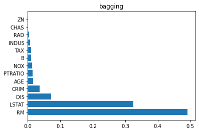

```python
import matplotlib.pyplot as plt

importance = pd.DataFrame(np.mean([tree.feature_importances_ for tree in model_bag_reg.estimators_], axis=0))
feature_importance = pd.concat([pd.DataFrame(X.columns), importance], axis=1)
feature_importance.columns = ['feature', 'importance']
feature_importance.sort_values('importance', inplace=True, ascending=False)
plt.barh(feature_importance["feature"], feature_importance["importance"], align='center')
plt.title('bagging')
```

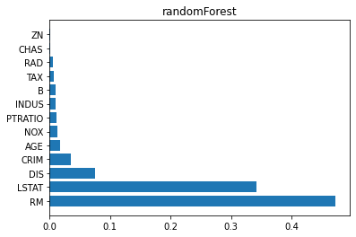

```python
importance = pd.DataFrame(np.mean([tree.feature_importances_ for tree in model_rf_reg.estimators_], axis=0))
feature_importance = pd.concat([pd.DataFrame(X.columns), importance], axis=1)
feature_importance.columns = ['feature', 'importance']
feature_importance.sort_values('importance', inplace=True, ascending=False)
feature_importance
plt.barh(feature_importance["feature"], feature_importance["importance"], align='center')
plt.title('randomForest')
```

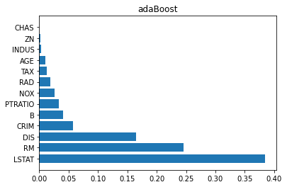

```python
importance = pd.DataFrame(np.mean([tree.feature_importances_ for tree in grid_ada_reg.best_estimator_.estimators_], axis=0))
feature_importance = pd.concat([pd.DataFrame(X.columns), importance], axis=1)
feature_importance.columns = ['feature', 'importance']
feature_importance.sort_values('importance', inplace=True, ascending=False)
feature_importance
plt.barh(feature_importance["feature"], feature_importance["importance"], align='center')
plt.title('adaBoost')
```

Score는 배깅 > 랜덤포레스트 > 부스팅 순으로 높음.

- 배깅: 0.8429958997273134
- 랜덤포레스트: 0.8388574459002247
- 부스팅: 0.8035072110103304

변수 중요도를 산출해봤을 때, 아래와 같으며 adaBoost의 경우 변수 중요도의 순서가 다르다.

- 배깅: RM > LSTAT > DIS > ...
- 랜덤포레스트: RM > LSTAT > DIS > ...
- adaBoost: LSTAT > RM > DIS > ...

## titanic데이터를 가지고 생존율을 예측하는 아래 3가지의 모델을 만들고 모델을 비교하고 최적 모델의 결과를 해석하세요

### 배깅

### 랜덤포래스트

### 부스팅

```python
df_t = pd.read_csv("./data/titanic.csv")
df_t
```

|  | survived | pclass | sex | age | sibsp | parch | fare | embarked | class | adult_male | embark_town |
| --- | --- | --- | --- | --- | --- | --- | --- | --- | --- | --- | --- |
| 0 | 0 | 3 | male | 22.0 | 1 | 0 | 7.2500 | S | Third | True | Southampton |
| 1 | 1 | 1 | female | 38.0 | 1 | 0 | 71.2833 | C | First | False | Cherbourg |
| 2 | 1 | 3 | female | 26.0 | 0 | 0 | 7.9250 | S | Third | False | Southampton |
| 3 | 1 | 1 | female | 35.0 | 1 | 0 | 53.1000 | S | First | False | Southampton |
| 4 | 0 | 3 | male | 35.0 | 0 | 0 | 8.0500 | S | Third | True | Southampton |
| ... | ... | ... | ... | ... | ... | ... | ... | ... | ... | ... | ... |
| 886 | 0 | 2 | male | 27.0 | 0 | 0 | 13.0000 | S | Second | True | Southampton |
| 887 | 1 | 1 | female | 19.0 | 0 | 0 | 30.0000 | S | First | False | Southampton |
| 888 | 0 | 3 | female | NaN | 1 | 2 | 23.4500 | S | Third | False | Southampton |
| 889 | 1 | 1 | male | 26.0 | 0 | 0 | 30.0000 | C | First | True | Cherbourg |
| 890 | 0 | 3 | male | 32.0 | 0 | 0 | 7.7500 | Q | Third | True | Queenstown |

891 rows × 11 columns

```python
y=df_t['survived']
X=df_t.drop(columns=['survived','pclass','embarked'])
```

```python
X.info()
```

```
<class 'pandas.core.frame.DataFrame'>
RangeIndex: 891 entries, 0 to 890
Data columns (total 8 columns):
 #   Column       Non-Null Count  Dtype
---  ------       --------------  -----
 0   sex          891 non-null    object
 1   age          714 non-null    float64
 2   sibsp        891 non-null    int64
 3   parch        891 non-null    int64
 4   fare         891 non-null    float64
 5   class        891 non-null    object
 6   adult_male   891 non-null    bool
 7   embark_town  889 non-null    object
dtypes: bool(1), float64(2), int64(2), object(3)
memory usage: 49.7+ KB
```

```python
X['age'].fillna(round(X['age'].mean()), inplace=True)
X['embark_town'].fillna(X['embark_town'].describe().top, inplace=True)
```

```python
X.info()
```

```
<class 'pandas.core.frame.DataFrame'>
RangeIndex: 891 entries, 0 to 890
Data columns (total 8 columns):
 #   Column       Non-Null Count  Dtype
---  ------       --------------  -----
 0   sex          891 non-null    object
 1   age          891 non-null    float64
 2   sibsp        891 non-null    int64
 3   parch        891 non-null    int64
 4   fare         891 non-null    float64
 5   class        891 non-null    object
 6   adult_male   891 non-null    bool
 7   embark_town  891 non-null    object
dtypes: bool(1), float64(2), int64(2), object(3)
memory usage: 49.7+ KB
```

```python
X = pd.get_dummies(columns=['sex','class','adult_male','embark_town'], data=X)
```

```python
from sklearn.model_selection import train_test_split

X_train, X_test, y_train, y_test = train_test_split(X,y, test_size = 0.3, random_state=2022)
```

```python
from sklearn.ensemble import BaggingClassifier
param_grid = {'max_features':range(1,10,2),'max_samples':range(1,10,2),'n_estimators':[50]}
grid_bag_clf = GridSearchCV(BaggingClassifier(), param_grid, cv=5)
grid_bag_clf.fit(X_train,y_train)
```

```
GridSearchCV(cv=5, estimator=BaggingClassifier(),
             param_grid={'max_features': range(1, 10, 2),
                         'max_samples': range(1, 10, 2), 'n_estimators': [50]})
```

```python
grid_bag_clf.best_estimator_.get_params()
```

```
{'base_estimator': None,
 'bootstrap': True,
 'bootstrap_features': False,
 'max_features': 7,
 'max_samples': 5,
 'n_estimators': 50,
 'n_jobs': None,
 'oob_score': False,
 'random_state': None,
 'verbose': 0,
 'warm_start': False}
```

```python
from sklearn.ensemble import RandomForestClassifier
param_grid = {'max_depth':range(1,10,2),'min_samples_leaf':range(1,10,2),'n_estimators':[50]}
grid_rf_clf = GridSearchCV(RandomForestClassifier(), param_grid, cv=5)
grid_rf_clf.fit(X_train,y_train)
```

```
GridSearchCV(cv=5, estimator=RandomForestClassifier(),
             param_grid={'max_depth': range(1, 10, 2),
                         'min_samples_leaf': range(1, 10, 2),
                         'n_estimators': [50]})
```

```python
grid_rf_clf.best_estimator_.get_params()
```

```
{'bootstrap': True,
 'ccp_alpha': 0.0,
 'class_weight': None,
 'criterion': 'gini',
 'max_depth': 7,
 'max_features': 'auto',
 'max_leaf_nodes': None,
 'max_samples': None,
 'min_impurity_decrease': 0.0,
 'min_samples_leaf': 1,
 'min_samples_split': 2,
 'min_weight_fraction_leaf': 0.0,
 'n_estimators': 50,
 'n_jobs': None,
 'oob_score': False,
 'random_state': None,
 'verbose': 0,
 'warm_start': False}
```

```python
import numpy as np
from sklearn.ensemble import AdaBoostClassifier
from sklearn.model_selection import GridSearchCV

param_grid = {'learning_rate':np.arange(0.1, 2, 0.1), 'n_estimators':[50]}


grid_ada_clf = GridSearchCV(AdaBoostClassifier(), param_grid, cv=5)
grid_ada_clf.fit(X_train,y_train)
```

```
GridSearchCV(cv=5, estimator=AdaBoostClassifier(),
             param_grid={'learning_rate': array([0.1, 0.2, 0.3, 0.4, 0.5, 0.6, 0.7, 0.8, 0.9, 1. , 1.1, 1.2, 1.3,
       1.4, 1.5, 1.6, 1.7, 1.8, 1.9]),
                         'n_estimators': [50]})
```

```python
grid_ada_clf.best_estimator_.get_params()
```

```
{'algorithm': 'SAMME.R',
 'base_estimator': None,
 'learning_rate': 1.1,
 'n_estimators': 50,
 'random_state': None}
```

```python
import numpy as np
from xgboost import XGBClassifier
from sklearn.model_selection import GridSearchCV

param_grid = {'max_depth':range(1,10,2),'learning_rate':np.arange(0.1, 2, 0.1), 'n_estimators':[50],'eval_metric':['mlogloss'],'use_label_encoder':[False]}


grid_xgb_clf = GridSearchCV(XGBClassifier(), param_grid, cv=5)
grid_xgb_clf.fit(X_train,y_train)
```

```
GridSearchCV(cv=5, estimator=XGBClassifier(),
             param_grid={'eval_metric': ['mlogloss'],
                         'learning_rate': array([0.1, 0.2, 0.3, 0.4, 0.5, 0.6, 0.7, 0.8, 0.9, 1. , 1.1, 1.2, 1.3,
       1.4, 1.5, 1.6, 1.7, 1.8, 1.9]),
                         'max_depth': range(1, 10, 2), 'n_estimators': [50],
                         'use_label_encoder': [False]})
```

```python
grid_xgb_clf.best_estimator_.get_params()
```

```
{'base_score': 0.5,
 'booster': 'gbtree',
 'colsample_bylevel': 1,
 'colsample_bynode': 1,
 'colsample_bytree': 1,
 'gamma': 0,
 'learning_rate': 0.30000000000000004,
 'max_delta_step': 0,
 'max_depth': 3,
 'min_child_weight': 1,
 'missing': None,
 'n_estimators': 50,
 'n_jobs': 1,
 'nthread': None,
 'objective': 'binary:logistic',
 'random_state': 0,
 'reg_alpha': 0,
 'reg_lambda': 1,
 'scale_pos_weight': 1,
 'seed': None,
 'silent': None,
 'subsample': 1,
 'verbosity': 1,
 'eval_metric': 'mlogloss',
 'use_label_encoder': False}
```

```python
# score 비교
print("배깅:",grid_bag_clf.best_estimator_.score(X_test,y_test))
print("랜덤포레스트:", grid_rf_clf.best_estimator_.score(X_test,y_test))
print("부스팅:",grid_ada_clf.best_estimator_.score(X_test, y_test))
print("XG부스팅:",grid_xgb_clf.best_estimator_.score(X_test, y_test))
```

```
배깅: 0.7910447761194029
랜덤포레스트: 0.832089552238806
부스팅: 0.8134328358208955
XG부스팅: 0.832089552238806
```

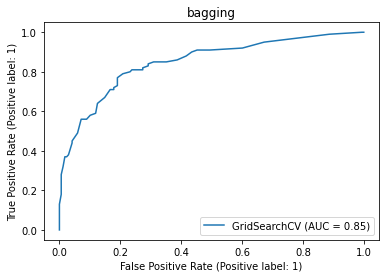

```python
from sklearn.metrics import plot_roc_curve

plot_roc_curve(grid_bag_clf, X_test, y_test)
plt.title('bagging')
plt.show()
```

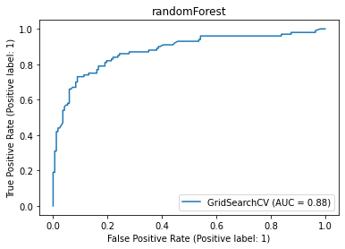

```python
plot_roc_curve(grid_rf_clf, X_test, y_test)
plt.title('randomForest')
plt.show()
```

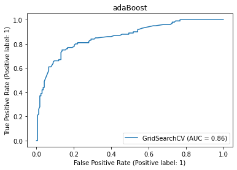

```python
plot_roc_curve(grid_ada_clf, X_test, y_test)
plt.title('adaBoost')
plt.show()
```

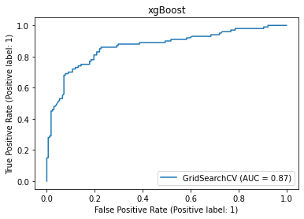

```python
plot_roc_curve(grid_xgb_clf, X_test, y_test)
plt.title('xgBoost')
plt.show()
```

survived=1 에 대한 정확도는 아래와 같고,

- 배깅: 0.7910447761194029
- 랜덤포레스트: 0.832089552238806
- 부스팅: 0.8134328358208955
- XG부스팅: 0.832089552238806

AUC_ROC_SCORE는 아래와 같다.

- 배깅: 0.85
- 랜덤포레스트: 0.88
- adaBoost: 0.86
- XGBoost: 0.87

따라서 survived=1,0 모두 잘 분류하는 성능은 auc_roc_score가 가장 높은 랜덤포레스트가 가장 좋다고 할 수 있다.

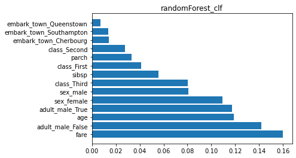

```python
importance = pd.DataFrame(np.mean([tree.feature_importances_ for tree in grid_rf_clf.best_estimator_.estimators_], axis=0))
feature_importance = pd.concat([pd.DataFrame(X.columns), importance], axis=1)
feature_importance.columns = ['feature', 'importance']
feature_importance.sort_values('importance', inplace=True, ascending=False)
feature_importance
plt.barh(feature_importance["feature"], feature_importance["importance"], align='center')
plt.title('randomForest_clf')
```

랜덤포레스트 모델에서 변수 중요도는 fare, adult_male, age, sex 순서로 중요하다고 알 수 있고,  
embark_town의 중요도는 낮다고 할 수 있다.

- fare > adult_male_False > age > adult_male_True > sex_female > ...